# Datathon 2026 - Access to Care

This data analysis project explores the National Health Interview Survey (NHIS) Adult Summary Health Statistics dataset, provided by the U.S. Centers for Disease Control and Prevention (CDC).

In this project, I explored and filtered out the data with FLAGs, indentify the topics, groups, and subgroups of interest, created data visualization using Tableau, and summarized my findings and recommendations.

```python
# libraries
import pandas as pd
import matplotlib.pyplot as plt
from IPython.display import Image
```

```python
# general functions

def print_column_unique(df, column):
    print(column + " unique: ")
    print(df[column].unique())
```

```python
# import dataset
df = pd.read_csv("Access_to_Care_Dataset.csv")

df
```

|  | TOPIC | SUBTOPIC | SUBTOPIC_ID | TAXONOMY | TAXONOMY_ID | CLASSIFICATION | CLASSIFICATION_ID | GROUP | GROUP_ID | GROUP_ORDER | ... | ESTIMATE_TYPE | ESTIMATE_TYPE_ID | TIME_PERIOD | TIME_PERIOD_ID | ESTIMATE | STANDARD_ERROR | ESTIMATE_LCI | ESTIMATE_UCI | FLAG | FOOTNOTE_ID_LIST |
| --- | --- | --- | --- | --- | --- | --- | --- | --- | --- | --- | --- | --- | --- | --- | --- | --- | --- | --- | --- | --- | --- |
| 0 | Angina/angina pectoris | NaN | NaN | Cardiovascular diseases | 60 | Total | 0 | Total | 1 | 1 | ... | Percent of population, crude | 1 | 2019 | NaN | 1.7 | NaN | 1.5 | 1.9 | NaN | NT_NHISA00,NT_NHISA999,FN_NHISA18,SC_NHISA00 |
| 1 | Angina/angina pectoris | NaN | NaN | Cardiovascular diseases | 60 | Total | 0 | Total | 1 | 1 | ... | Percent of population, crude | 1 | 2020 | NaN | 1.5 | NaN | 1.3 | 1.6 | NaN | NT_NHISA00,NT_NHISA999,FN_NHISA18,SC_NHISA00 |
| 2 | Angina/angina pectoris | NaN | NaN | Cardiovascular diseases | 60 | Total | 0 | Total | 1 | 1 | ... | Percent of population, crude | 1 | 2021 | NaN | 1.5 | NaN | 1.4 | 1.7 | NaN | NT_NHISA00,NT_NHISA999,FN_NHISA18,SC_NHISA00 |
| 3 | Angina/angina pectoris | NaN | NaN | Cardiovascular diseases | 60 | Total | 0 | Total | 1 | 1 | ... | Percent of population, crude | 1 | 2022 | NaN | 1.6 | NaN | 1.5 | 1.8 | NaN | NT_NHISA00,NT_NHISA999,FN_NHISA18,SC_NHISA00 |
| 4 | Angina/angina pectoris | NaN | NaN | Cardiovascular diseases | 60 | Total | 0 | Total | 1 | 1 | ... | Percent of population, crude | 1 | 2023 | NaN | 1.6 | NaN | 1.4 | 1.8 | NaN | NT_NHISA00,NT_NHISA999,FN_NHISA18,SC_NHISA00 |
| ... | ... | ... | ... | ... | ... | ... | ... | ... | ... | ... | ... | ... | ... | ... | ... | ... | ... | ... | ... | ... | ... |
| 26203 | Wellness visit | NaN | NaN | Healthcare system use | 170 | Socioeconomic Characteristic | 3 | Poverty level | 21 | 21 | ... | Percent of population, crude | 1 | 2020 | NaN | 78.9 | NaN | 78.2 | 79.6 | NaN | NT_NHISA00,NT_NHISA999,FN_NHISA11,FN_NHISA58,S... |
| 26204 | Wellness visit | NaN | NaN | Healthcare system use | 170 | Socioeconomic Characteristic | 3 | Poverty level | 21 | 21 | ... | Percent of population, crude | 1 | 2021 | NaN | 77.0 | NaN | 76.2 | 77.7 | NaN | NT_NHISA00,NT_NHISA999,FN_NHISA11,FN_NHISA58,S... |
| 26205 | Wellness visit | NaN | NaN | Healthcare system use | 170 | Socioeconomic Characteristic | 3 | Poverty level | 21 | 21 | ... | Percent of population, crude | 1 | 2022 | NaN | 78.8 | NaN | 78.0 | 79.5 | NaN | NT_NHISA00,NT_NHISA999,FN_NHISA11,FN_NHISA58,S... |
| 26206 | Wellness visit | NaN | NaN | Healthcare system use | 170 | Socioeconomic Characteristic | 3 | Poverty level | 21 | 21 | ... | Percent of population, crude | 1 | 2023 | NaN | 80.5 | NaN | 79.8 | 81.2 | NaN | NT_NHISA00,NT_NHISA999,FN_NHISA11,FN_NHISA58,S... |
| 26207 | Wellness visit | NaN | NaN | Healthcare system use | 170 | Socioeconomic Characteristic | 3 | Poverty level | 21 | 21 | ... | Percent of population, crude | 1 | 2024 | NaN | 82.0 | NaN | 81.3 | 82.6 | NaN | NT_NHISA00,NT_NHISA999,FN_NHISA11,FN_NHISA58,S... |

26208 rows × 25 columns

## Exploring and Cleaning Data

In this section, I explored the general nature and the attributes of the dataset. In addition, explored the different types of FLAGs and filtered them out to exclude less reliable data from further analysis.

```python
# list columns
print("Columns headers:")
print(df.columns)

# unique flags
print_column_unique(df, "FLAG")
```

```
Columns headers:
Index(['TOPIC', 'SUBTOPIC', 'SUBTOPIC_ID', 'TAXONOMY', 'TAXONOMY_ID',
       'CLASSIFICATION', 'CLASSIFICATION_ID', 'GROUP', 'GROUP_ID',
       'GROUP_ORDER', 'SUBGROUP', 'SUBGROUP_ID', 'SUBGROUP_ORDER',
       'NESTING_LABEL', 'NESTING_LABEL_ID', 'ESTIMATE_TYPE',
       'ESTIMATE_TYPE_ID', 'TIME_PERIOD', 'TIME_PERIOD_ID', 'ESTIMATE',
       'STANDARD_ERROR', 'ESTIMATE_LCI', 'ESTIMATE_UCI', 'FLAG',
       'FOOTNOTE_ID_LIST'],
      dtype='object')
FLAG unique:
[nan '*' '-' '~' '****' '**' '---' '***']
```

```python
# find flags indicating unreliable estimate
df.loc[df["FLAG"] == '***']
```

|  | TOPIC | SUBTOPIC | SUBTOPIC_ID | TAXONOMY | TAXONOMY_ID | CLASSIFICATION | CLASSIFICATION_ID | GROUP | GROUP_ID | GROUP_ORDER | ... | ESTIMATE_TYPE | ESTIMATE_TYPE_ID | TIME_PERIOD | TIME_PERIOD_ID | ESTIMATE | STANDARD_ERROR | ESTIMATE_LCI | ESTIMATE_UCI | FLAG | FOOTNOTE_ID_LIST |
| --- | --- | --- | --- | --- | --- | --- | --- | --- | --- | --- | --- | --- | --- | --- | --- | --- | --- | --- | --- | --- | --- |
| 13596 | Exchange-based coverage at time of interview a... | NaN | NaN | Health insurance | 120 | Demographic Characteristic | 1 | Age groups with 65 years and older | 2 | 2 | ... | Percent of population, crude | 1 | 2019 | NaN | NaN | NaN | NaN | NaN | *** | NA_NHISA11,NT_NHISA00,NT_NHISA999,FN_NHISA68,S... |
| 13597 | Exchange-based coverage at time of interview a... | NaN | NaN | Health insurance | 120 | Demographic Characteristic | 1 | Age groups with 65 years and older | 2 | 2 | ... | Percent of population, crude | 1 | 2020 | NaN | NaN | NaN | NaN | NaN | *** | NA_NHISA11,NT_NHISA00,NT_NHISA999,FN_NHISA68,S... |
| 13598 | Exchange-based coverage at time of interview a... | NaN | NaN | Health insurance | 120 | Demographic Characteristic | 1 | Age groups with 65 years and older | 2 | 2 | ... | Percent of population, crude | 1 | 2021 | NaN | NaN | NaN | NaN | NaN | *** | NA_NHISA11,NT_NHISA00,NT_NHISA999,FN_NHISA68,S... |
| 13599 | Exchange-based coverage at time of interview a... | NaN | NaN | Health insurance | 120 | Demographic Characteristic | 1 | Age groups with 65 years and older | 2 | 2 | ... | Percent of population, crude | 1 | 2022 | NaN | NaN | NaN | NaN | NaN | *** | NA_NHISA11,NT_NHISA00,NT_NHISA999,FN_NHISA68,S... |
| 13600 | Exchange-based coverage at time of interview a... | NaN | NaN | Health insurance | 120 | Demographic Characteristic | 1 | Age groups with 65 years and older | 2 | 2 | ... | Percent of population, crude | 1 | 2023 | NaN | NaN | NaN | NaN | NaN | *** | NA_NHISA11,NT_NHISA00,NT_NHISA999,FN_NHISA68,S... |
| ... | ... | ... | ... | ... | ... | ... | ... | ... | ... | ... | ... | ... | ... | ... | ... | ... | ... | ... | ... | ... | ... |
| 23353 | Uninsured at time of interview among adults | NaN | NaN | Health insurance | 120 | Socioeconomic Characteristic | 3 | Health insurance coverage: 65 years and older | 19 | 19 | ... | Percent of population, crude | 1 | 2020 | NaN | NaN | NaN | NaN | NaN | *** | NA_NHISA11,NT_NHISA00,NT_NHISA999,FN_NHISA09,F... |
| 23354 | Uninsured at time of interview among adults | NaN | NaN | Health insurance | 120 | Socioeconomic Characteristic | 3 | Health insurance coverage: 65 years and older | 19 | 19 | ... | Percent of population, crude | 1 | 2021 | NaN | NaN | NaN | NaN | NaN | *** | NA_NHISA11,NT_NHISA00,NT_NHISA999,FN_NHISA09,F... |
| 23355 | Uninsured at time of interview among adults | NaN | NaN | Health insurance | 120 | Socioeconomic Characteristic | 3 | Health insurance coverage: 65 years and older | 19 | 19 | ... | Percent of population, crude | 1 | 2022 | NaN | NaN | NaN | NaN | NaN | *** | NA_NHISA11,NT_NHISA00,NT_NHISA999,FN_NHISA09,F... |
| 23356 | Uninsured at time of interview among adults | NaN | NaN | Health insurance | 120 | Socioeconomic Characteristic | 3 | Health insurance coverage: 65 years and older | 19 | 19 | ... | Percent of population, crude | 1 | 2023 | NaN | NaN | NaN | NaN | NaN | *** | NA_NHISA11,NT_NHISA00,NT_NHISA999,FN_NHISA09,F... |
| 23357 | Uninsured at time of interview among adults | NaN | NaN | Health insurance | 120 | Socioeconomic Characteristic | 3 | Health insurance coverage: 65 years and older | 19 | 19 | ... | Percent of population, crude | 1 | 2024 | NaN | NaN | NaN | NaN | NaN | *** | NA_NHISA11,NT_NHISA00,NT_NHISA999,FN_NHISA09,F... |

216 rows × 25 columns

```python
# FLAG key
# '-': estimate = 0.0, no 95% CI
# '---': no estimate, no 95% CI
# '*': no nothing
# '**': w/ estimate, no SE, w/ 95% CI
# '***': no nothing
# '****': no nothing
# '~': estimate = 0.0, no SE, with 95% CI
```

```python
# filter out flags
df_clean = df.loc[df["FLAG"].isna()]

df_clean
```

|  | TOPIC | SUBTOPIC | SUBTOPIC_ID | TAXONOMY | TAXONOMY_ID | CLASSIFICATION | CLASSIFICATION_ID | GROUP | GROUP_ID | GROUP_ORDER | ... | ESTIMATE_TYPE | ESTIMATE_TYPE_ID | TIME_PERIOD | TIME_PERIOD_ID | ESTIMATE | STANDARD_ERROR | ESTIMATE_LCI | ESTIMATE_UCI | FLAG | FOOTNOTE_ID_LIST |
| --- | --- | --- | --- | --- | --- | --- | --- | --- | --- | --- | --- | --- | --- | --- | --- | --- | --- | --- | --- | --- | --- |
| 0 | Angina/angina pectoris | NaN | NaN | Cardiovascular diseases | 60 | Total | 0 | Total | 1 | 1 | ... | Percent of population, crude | 1 | 2019 | NaN | 1.7 | NaN | 1.5 | 1.9 | NaN | NT_NHISA00,NT_NHISA999,FN_NHISA18,SC_NHISA00 |
| 1 | Angina/angina pectoris | NaN | NaN | Cardiovascular diseases | 60 | Total | 0 | Total | 1 | 1 | ... | Percent of population, crude | 1 | 2020 | NaN | 1.5 | NaN | 1.3 | 1.6 | NaN | NT_NHISA00,NT_NHISA999,FN_NHISA18,SC_NHISA00 |
| 2 | Angina/angina pectoris | NaN | NaN | Cardiovascular diseases | 60 | Total | 0 | Total | 1 | 1 | ... | Percent of population, crude | 1 | 2021 | NaN | 1.5 | NaN | 1.4 | 1.7 | NaN | NT_NHISA00,NT_NHISA999,FN_NHISA18,SC_NHISA00 |
| 3 | Angina/angina pectoris | NaN | NaN | Cardiovascular diseases | 60 | Total | 0 | Total | 1 | 1 | ... | Percent of population, crude | 1 | 2022 | NaN | 1.6 | NaN | 1.5 | 1.8 | NaN | NT_NHISA00,NT_NHISA999,FN_NHISA18,SC_NHISA00 |
| 4 | Angina/angina pectoris | NaN | NaN | Cardiovascular diseases | 60 | Total | 0 | Total | 1 | 1 | ... | Percent of population, crude | 1 | 2023 | NaN | 1.6 | NaN | 1.4 | 1.8 | NaN | NT_NHISA00,NT_NHISA999,FN_NHISA18,SC_NHISA00 |
| ... | ... | ... | ... | ... | ... | ... | ... | ... | ... | ... | ... | ... | ... | ... | ... | ... | ... | ... | ... | ... | ... |
| 26203 | Wellness visit | NaN | NaN | Healthcare system use | 170 | Socioeconomic Characteristic | 3 | Poverty level | 21 | 21 | ... | Percent of population, crude | 1 | 2020 | NaN | 78.9 | NaN | 78.2 | 79.6 | NaN | NT_NHISA00,NT_NHISA999,FN_NHISA11,FN_NHISA58,S... |
| 26204 | Wellness visit | NaN | NaN | Healthcare system use | 170 | Socioeconomic Characteristic | 3 | Poverty level | 21 | 21 | ... | Percent of population, crude | 1 | 2021 | NaN | 77.0 | NaN | 76.2 | 77.7 | NaN | NT_NHISA00,NT_NHISA999,FN_NHISA11,FN_NHISA58,S... |
| 26205 | Wellness visit | NaN | NaN | Healthcare system use | 170 | Socioeconomic Characteristic | 3 | Poverty level | 21 | 21 | ... | Percent of population, crude | 1 | 2022 | NaN | 78.8 | NaN | 78.0 | 79.5 | NaN | NT_NHISA00,NT_NHISA999,FN_NHISA11,FN_NHISA58,S... |
| 26206 | Wellness visit | NaN | NaN | Healthcare system use | 170 | Socioeconomic Characteristic | 3 | Poverty level | 21 | 21 | ... | Percent of population, crude | 1 | 2023 | NaN | 80.5 | NaN | 79.8 | 81.2 | NaN | NT_NHISA00,NT_NHISA999,FN_NHISA11,FN_NHISA58,S... |
| 26207 | Wellness visit | NaN | NaN | Healthcare system use | 170 | Socioeconomic Characteristic | 3 | Poverty level | 21 | 21 | ... | Percent of population, crude | 1 | 2024 | NaN | 82.0 | NaN | 81.3 | 82.6 | NaN | NT_NHISA00,NT_NHISA999,FN_NHISA11,FN_NHISA58,S... |

23609 rows × 25 columns

## Identifying Areas of Interest and Analysis

In this section, I explored different ways of grouping the dataset, including year, classification, topic, group, and subgroups. Using the taxonomy column, I found the topics that are the most relevant to this project. I made a separate Dataframe that includes just the topics and attributes of interest for analysis. I sorted the data in different ways to show the types of population that are most affected by each situation. Through these exploration, I identified the topics and groups that I would like to visualize in the next section.

```python
# find some demographic groups

# print("CLASSIFICATION unique: ")
# print(df_clean["CLASSIFICATION"].unique())

# print("\n" + "GROUP unique: ")
# print(df_clean["GROUP"].unique())

# print("\n" + "SUBGROUP unique: ")
# print(df_clean["SUBGROUP"].unique())

# df_clean.groupby
df_groups = df_clean[["TIME_PERIOD", "CLASSIFICATION", "GROUP", "SUBGROUP", "ESTIMATE"]
                     ].groupby(["TIME_PERIOD", "CLASSIFICATION", "GROUP", "SUBGROUP"]
                               ).mean("ESTIMATE")
display(df_groups)
```

| TIME_PERIOD | CLASSIFICATION | GROUP | SUBGROUP | ESTIMATE |
| --- | --- | --- | --- | --- |
| 2019 | Demographic Characteristic | Age groups with 65 years and older | 18-34 years | 17.316981 |
|  |  |  | 35-49 years | 19.044444 |
|  |  |  | 50-64 years | 23.044444 |
|  |  |  | 65 years and older | 28.697917 |
|  |  | Age groups with 75 years and older | 18-44 years | 17.835849 |
| ... | ... | ... | ... | ... |
| 2024 | Socioeconomic Characteristic | Health insurance coverage: Younger than 65 years | Uninsured | 18.736735 |
|  |  | Poverty level | 100% to <200% FPL | 21.398077 |
|  |  |  | <100% FPL | 22.278846 |
|  |  |  | ???200% FPL | 19.073077 |
|  | Total | Total | 18 years and older | 19.803846 |

466 rows × 1 columns

```python
# explore topic, estimate type, and estimate percentage

print_column_unique(df_clean, "TOPIC")

print_column_unique(df_clean, "ESTIMATE_TYPE")

df_clean["ESTIMATE"].describe()
```

```
TOPIC unique:
['Angina/angina pectoris' 'Any cancer type' 'Any difficulty communicating'
 'Any difficulty hearing' 'Any difficulty remembering or concentrating'
 'Any difficulty seeing' 'Any difficulty walking or climbing steps'
 'Any difficulty with self care' 'Any skin cancer' 'Arthritis diagnosis'
 'Asthma episode/attack in adults' 'Blood pressure check' 'Breast cancer'
 'COPD, emphysema, chronic bronchitis' 'Cervical cancer'
 'Coronary heart disease' 'Counseled by a mental health professional'
 'Current asthma in adults' 'Current cigarette smoking'
 'Current electronic cigarette or vaping product use'
 'Delayed getting medical care due to cost among adults'
 'Dental exam or cleaning' 'Diabetes diagnosis, self-reported'
 'Did not get needed medical care due to cost'
 'Did not get needed mental health care due to cost'
 'Did not take medication as prescribed to save money'
 'Disability status (composite) among adults' 'Doctor visit among adults'
 'Ever received a pneumococcal vaccination'
 'Exchange-based coverage at time of interview among adults'
 'Fair or poor health status in adults'
 'Functioning difficulties status (composite) among adults'
 'Has a usual place of care among adults'
 'Heart attack/myocardial infarction'
 'High cholesterol diagnosis, self-reported'
 'Hospital emergency department visit'
 'Hypertension diagnosis, self-reported'
 'Obesity in adults, self-reported'
 'Prescription medication use among adults'
 'Private health insurance coverage at time of interview among adults'
 'Prostate cancer'
 'Public health insurance coverage at time of interview among adults'
 'Receipt of influenza vaccination among adults'
 'Regularly experienced chronic pain'
 'Regularly had feelings of depression'
 'Regularly had feelings of worry, nervousness, or anxiety'
 'Six or more workdays missed due to illness, injury, or disability'
 'Taking prescription medication for feelings of depression'
 'Taking prescription medication for feelings of worry, nervousness, or anxiety'
 'Uninsured at time of interview among adults'
 'Uninsured for at least part of the past year among adults'
 'Uninsured for more than one year among adults'
 'Urgent care center or retail health clinic visit among adults:'
 'Wellness visit']
ESTIMATE_TYPE unique:
['Percent of population, crude']
```

```
count    23609.000000
mean        22.068809
std         23.932012
min          0.100000
25%          5.800000
50%         12.800000
75%         26.900000
max        100.000000
Name: ESTIMATE, dtype: float64
```

Topics related to health care access:

- Delayed getting medical care due to cost among adults
- Did not get needed medical care due to cost
- Did not get needed mental health care due to cost
- Did not take medication as prescribed to save money
- Has a usual place of care among adults
- Uninsured at time of interview among adults
- Uninsured for at least part of the past year among adults
- Uninsured for more than one year among adults

```python
# examine estimate percentage = 100
df_clean[df_clean["ESTIMATE"] == 100].head(10)

# disability, insurance situation
# -> not super valuable
```

|  | TOPIC | SUBTOPIC | SUBTOPIC_ID | TAXONOMY | TAXONOMY_ID | CLASSIFICATION | CLASSIFICATION_ID | GROUP | GROUP_ID | GROUP_ORDER | ... | ESTIMATE_TYPE | ESTIMATE_TYPE_ID | TIME_PERIOD | TIME_PERIOD_ID | ESTIMATE | STANDARD_ERROR | ESTIMATE_LCI | ESTIMATE_UCI | FLAG | FOOTNOTE_ID_LIST |
| --- | --- | --- | --- | --- | --- | --- | --- | --- | --- | --- | --- | --- | --- | --- | --- | --- | --- | --- | --- | --- | --- |
| 12222 | Disability status (composite) among adults | NaN | NaN | Functioning and disability | 100 | Demographic Characteristic | 1 | Disability status | 4 | 4 | ... | Percent of population, crude | 1 | 2019 | NaN | 100.0 | NaN | 99.9 | 100.0 | NaN | NT_NHISA00,NT_NHISA999,FN_NHISA13,FN_NHISA69,S... |
| 12223 | Disability status (composite) among adults | NaN | NaN | Functioning and disability | 100 | Demographic Characteristic | 1 | Disability status | 4 | 4 | ... | Percent of population, crude | 1 | 2020 | NaN | 100.0 | NaN | 99.9 | 100.0 | NaN | NT_NHISA00,NT_NHISA999,FN_NHISA13,FN_NHISA69,S... |
| 12224 | Disability status (composite) among adults | NaN | NaN | Functioning and disability | 100 | Demographic Characteristic | 1 | Disability status | 4 | 4 | ... | Percent of population, crude | 1 | 2021 | NaN | 100.0 | NaN | 99.9 | 100.0 | NaN | NT_NHISA00,NT_NHISA999,FN_NHISA13,FN_NHISA69,S... |
| 12225 | Disability status (composite) among adults | NaN | NaN | Functioning and disability | 100 | Demographic Characteristic | 1 | Disability status | 4 | 4 | ... | Percent of population, crude | 1 | 2022 | NaN | 100.0 | NaN | 99.9 | 100.0 | NaN | NT_NHISA00,NT_NHISA999,FN_NHISA13,FN_NHISA69,S... |
| 12226 | Disability status (composite) among adults | NaN | NaN | Functioning and disability | 100 | Demographic Characteristic | 1 | Disability status | 4 | 4 | ... | Percent of population, crude | 1 | 2023 | NaN | 100.0 | NaN | 99.9 | 100.0 | NaN | NT_NHISA00,NT_NHISA999,FN_NHISA13,FN_NHISA69,S... |
| 12227 | Disability status (composite) among adults | NaN | NaN | Functioning and disability | 100 | Demographic Characteristic | 1 | Disability status | 4 | 4 | ... | Percent of population, crude | 1 | 2024 | NaN | 100.0 | NaN | 99.9 | 100.0 | NaN | NT_NHISA00,NT_NHISA999,FN_NHISA13,FN_NHISA69,S... |
| 14562 | Functioning difficulties status (composite) am... | NaN | NaN | Functioning and disability | 100 | Demographic Characteristic | 1 | Disability status | 4 | 4 | ... | Percent of population, crude | 1 | 2019 | NaN | 100.0 | NaN | 99.9 | 100.0 | NaN | NT_NHISA00,NT_NHISA999,FN_NHISA13,FN_NHISA72,S... |
| 14563 | Functioning difficulties status (composite) am... | NaN | NaN | Functioning and disability | 100 | Demographic Characteristic | 1 | Disability status | 4 | 4 | ... | Percent of population, crude | 1 | 2020 | NaN | 100.0 | NaN | 99.9 | 100.0 | NaN | NT_NHISA00,NT_NHISA999,FN_NHISA13,FN_NHISA72,S... |
| 14564 | Functioning difficulties status (composite) am... | NaN | NaN | Functioning and disability | 100 | Demographic Characteristic | 1 | Disability status | 4 | 4 | ... | Percent of population, crude | 1 | 2021 | NaN | 100.0 | NaN | 99.9 | 100.0 | NaN | NT_NHISA00,NT_NHISA999,FN_NHISA13,FN_NHISA72,S... |
| 14565 | Functioning difficulties status (composite) am... | NaN | NaN | Functioning and disability | 100 | Demographic Characteristic | 1 | Disability status | 4 | 4 | ... | Percent of population, crude | 1 | 2022 | NaN | 100.0 | NaN | 99.9 | 100.0 | NaN | NT_NHISA00,NT_NHISA999,FN_NHISA13,FN_NHISA72,S... |

10 rows × 25 columns

```python
# find taxonomy
print_column_unique(df_clean, "TAXONOMY")

df_clean.loc[df_clean["TAXONOMY"] == "Healthcare access and quality", "TOPIC"].unique()
```

```
TAXONOMY unique:
['Cardiovascular diseases' 'Cancer' 'Functioning and disability'
 'Arthritis' 'Asthma' 'Healthcare system use'
 'Chronic obstructive pulmonary disease' 'Mental wellness'
 'Substance use and abuse' 'Healthcare access and quality' 'Oral health'
 'Diabetes' 'Vaccines and vaccination' 'Health insurance' 'Health status'
 'Overweight and obesity' 'Prescription drugs and medicines' 'Pain'
 'Workplace attendance and absenteeism']
```

```
array(['Delayed getting medical care due to cost among adults',
       'Did not get needed medical care due to cost',
       'Did not get needed mental health care due to cost',
       'Did not take medication as prescribed to save money',
       'Has a usual place of care among adults'], dtype=object)
```

```python
# make df_access with health care related topics & columns we care about
df_access = df_clean.loc[
    df_clean["TAXONOMY"] == "Healthcare access and quality",
    ["TOPIC", "CLASSIFICATION", "GROUP", "SUBGROUP", "ESTIMATE", "TIME_PERIOD"]]

df_access
```

|  | TOPIC | CLASSIFICATION | GROUP | SUBGROUP | ESTIMATE | TIME_PERIOD |
| --- | --- | --- | --- | --- | --- | --- |
| 9360 | Delayed getting medical care due to cost among... | Total | Total | 18 years and older | 9.1 | 2019 |
| 9361 | Delayed getting medical care due to cost among... | Total | Total | 18 years and older | 7.5 | 2020 |
| 9362 | Delayed getting medical care due to cost among... | Total | Total | 18 years and older | 7.1 | 2021 |
| 9363 | Delayed getting medical care due to cost among... | Total | Total | 18 years and older | 7.0 | 2022 |
| 9364 | Delayed getting medical care due to cost among... | Total | Total | 18 years and older | 7.2 | 2023 |
| ... | ... | ... | ... | ... | ... | ... |
| 15439 | Has a usual place of care among adults | Socioeconomic Characteristic | Poverty level | ???200% FPL | 90.5 | 2020 |
| 15440 | Has a usual place of care among adults | Socioeconomic Characteristic | Poverty level | ???200% FPL | 90.0 | 2021 |
| 15441 | Has a usual place of care among adults | Socioeconomic Characteristic | Poverty level | ???200% FPL | 89.9 | 2022 |
| 15442 | Has a usual place of care among adults | Socioeconomic Characteristic | Poverty level | ???200% FPL | 89.6 | 2023 |
| 15443 | Has a usual place of care among adults | Socioeconomic Characteristic | Poverty level | ???200% FPL | 90.5 | 2024 |

2261 rows × 6 columns

```python
# find the top 5 groups/subgroups experiencing most rates of unmet care
display(df_access.loc[
    df_access["TOPIC"] != "Has a usual place of care among adults"
    ].sort_values(by="ESTIMATE", ascending=False).head(5))

display(df_access.loc[
    df_access["TOPIC"] == "Has a usual place of care among adults"
    ].sort_values(by="ESTIMATE", ascending=True).head(5))
```

|  | TOPIC | CLASSIFICATION | GROUP | SUBGROUP | ESTIMATE | TIME_PERIOD |
| --- | --- | --- | --- | --- | --- | --- |
| 9804 | Delayed getting medical care due to cost among... | Socioeconomic Characteristic | Health insurance coverage: Younger than 65 years | Uninsured | 32.1 | 2019 |
| 12145 | Did not take medication as prescribed to save ... | Socioeconomic Characteristic | Health insurance coverage: Younger than 65 years | Uninsured | 30.6 | 2020 |
| 11208 | Did not get needed medical care due to cost | Socioeconomic Characteristic | Health insurance coverage: Younger than 65 years | Uninsured | 30.2 | 2019 |
| 12144 | Did not take medication as prescribed to save ... | Socioeconomic Characteristic | Health insurance coverage: Younger than 65 years | Uninsured | 29.0 | 2019 |
| 11447 | Did not get needed mental health care due to cost | Demographic Characteristic | Sexual orientation | Bisexual | 28.5 | 2024 |

|  | TOPIC | CLASSIFICATION | GROUP | SUBGROUP | ESTIMATE | TIME_PERIOD |
| --- | --- | --- | --- | --- | --- | --- |
| 15423 | Has a usual place of care among adults | Socioeconomic Characteristic | Health insurance coverage: Younger than 65 years | Uninsured | 56.9 | 2022 |
| 15424 | Has a usual place of care among adults | Socioeconomic Characteristic | Health insurance coverage: Younger than 65 years | Uninsured | 57.2 | 2023 |
| 15422 | Has a usual place of care among adults | Socioeconomic Characteristic | Health insurance coverage: Younger than 65 years | Uninsured | 59.1 | 2021 |
| 15420 | Has a usual place of care among adults | Socioeconomic Characteristic | Health insurance coverage: Younger than 65 years | Uninsured | 59.2 | 2019 |
| 15425 | Has a usual place of care among adults | Socioeconomic Characteristic | Health insurance coverage: Younger than 65 years | Uninsured | 59.3 | 2024 |

```python
print_column_unique(df_access, "GROUP")
df_access.loc[df_access["GROUP"] == "Employment status"].groupby("SUBGROUP").mean("ESTIMATE")
```

```
GROUP unique:
['Total' 'Age groups with 65 years and older'
 'Age groups with 75 years and older' 'Disability status'
 'Functioning difficulties status' 'Marital status' 'Nativity' 'Race'
 'Race and Hispanic origin' 'Sex' 'Sexual orientation' 'Veteran status'
 'Metropolitan statistical area' 'Region' 'Social vulnerability'
 'Urbanicity' 'Education' 'Employment status'
 'Health insurance coverage: 65 years and older'
 'Health insurance coverage: Younger than 65 years' 'Poverty level']
```

| SUBGROUP | ESTIMATE | TIME_PERIOD |
| --- | --- | --- |
| Employed | 23.056667 | 2021.500000 |
| Employed - Full-time | 22.836667 | 2021.500000 |
| Employed - Part-time | 24.030000 | 2021.500000 |
| Not employed | 23.113333 | 2021.500000 |
| Not employed - Has never worked | 21.989286 | 2021.535714 |
| Not employed - Has worked previously | 23.290000 | 2021.500000 |

Demographic areas to plot:

- Age groups with 65 years and older
- Race
- Sex
- Sexual orientation
- Region
- Employment status

Topics related to health care access:

- Delayed getting medical care due to cost among adults
- Did not get needed medical care due to cost
- Did not get needed mental health care due to cost
- Did not take medication as prescribed to save money
- Has a usual place of care among adults -> reverse: doesn't have a usual place of care amoung adults

```python
# reverse the has usual place of care

# df_access.loc[df_access["TOPIC"] == "Has a usual place of care among adults"]
df_access["REVERSE_ESTIMATE"] = (100 - df_access["ESTIMATE"])

df_access
```

|  | TOPIC | CLASSIFICATION | GROUP | SUBGROUP | ESTIMATE | TIME_PERIOD | REVERSE_ESTIMATE |
| --- | --- | --- | --- | --- | --- | --- | --- |
| 9360 | Delayed getting medical care due to cost among... | Total | Total | 18 years and older | 9.1 | 2019 | 90.9 |
| 9361 | Delayed getting medical care due to cost among... | Total | Total | 18 years and older | 7.5 | 2020 | 92.5 |
| 9362 | Delayed getting medical care due to cost among... | Total | Total | 18 years and older | 7.1 | 2021 | 92.9 |
| 9363 | Delayed getting medical care due to cost among... | Total | Total | 18 years and older | 7.0 | 2022 | 93.0 |
| 9364 | Delayed getting medical care due to cost among... | Total | Total | 18 years and older | 7.2 | 2023 | 92.8 |
| ... | ... | ... | ... | ... | ... | ... | ... |
| 15439 | Has a usual place of care among adults | Socioeconomic Characteristic | Poverty level | ???200% FPL | 90.5 | 2020 | 9.5 |
| 15440 | Has a usual place of care among adults | Socioeconomic Characteristic | Poverty level | ???200% FPL | 90.0 | 2021 | 10.0 |
| 15441 | Has a usual place of care among adults | Socioeconomic Characteristic | Poverty level | ???200% FPL | 89.9 | 2022 | 10.1 |
| 15442 | Has a usual place of care among adults | Socioeconomic Characteristic | Poverty level | ???200% FPL | 89.6 | 2023 | 10.4 |
| 15443 | Has a usual place of care among adults | Socioeconomic Characteristic | Poverty level | ???200% FPL | 90.5 | 2024 | 9.5 |

2261 rows × 7 columns

## Data Visualization: Tableau

In this section, I exported the dataframe and moved to Tableau to create data visualizations. I separated the data by group/subgroup and year (time period) to create two displays that show trends.

```python
# export df_access csv

df_access.to_csv("Cleaned_Access_to_Care_Dataset.csv")
```

### Dashboard 1: Separate By Group/Subgroup

In Tableau, I investigated the average of the following topics:

- Delayed getting medical care due to cost among adults
- Did not get needed medical care due to cost
- Did not get needed mental health care due to cost
- Did not take medication as prescribed to save money

Split by the subgroups under the following groups:

- Age groups with 65 years and older
- Race
- Sex
- Sexual orientation
- Region
- Employment status

From the visualization from Tableau, we found that in terms of healthcare:

- Younger people have less access
- Region-wise, the South has the least access, whereas the Northeast has the most access
- Native Hawaiian or Other Pacific Islander and Black and White have the least access, Asians have the most access
- Man have more access than woman
- Bisexuals have less access than straight or homosexual people
- Part-time employees have the least access, and Not employed - Has never worked have the most access

[Link to the Tableau Dashboard](https://public.tableau.com/views/Datathon2026_Access_to_Care/Dashboard1?:language=en-US&:sid=&:redirect=auth&:display_count=n&:origin=viz_share_link)

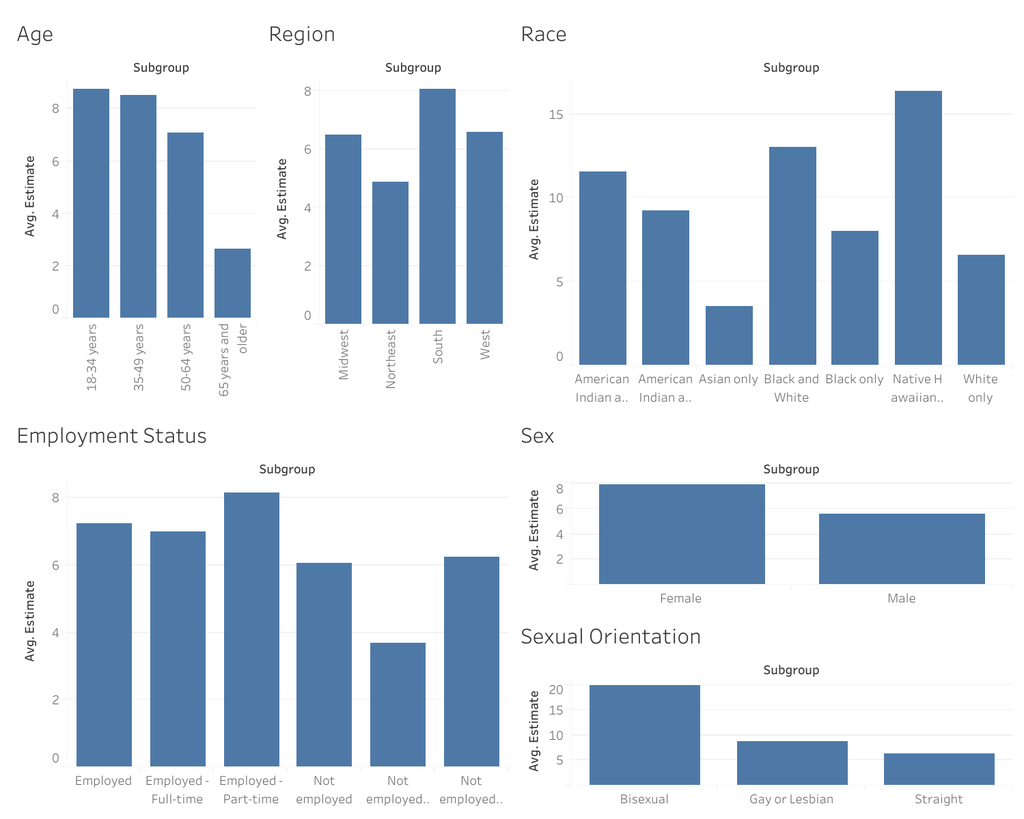

```python
Image(filename="Dashboard_by_gp.png")
```

### Dashboard 2: Separate By Year

In Tableau, I also looked at the trend of healthcare access over the time period 2019-2024. I looked at the average of all groups, as well as separated each group and subgroup.

On average, access to health increased between 2019 and 2021, but then decrease after 2022 (more people reported health-access issues).

[Link to the Tableau Dashboard](https://public.tableau.com/app/profile/yvonne.wang8591/viz/Datathon2026_Access_to_Care_by_time/Dashboardbytime#1)

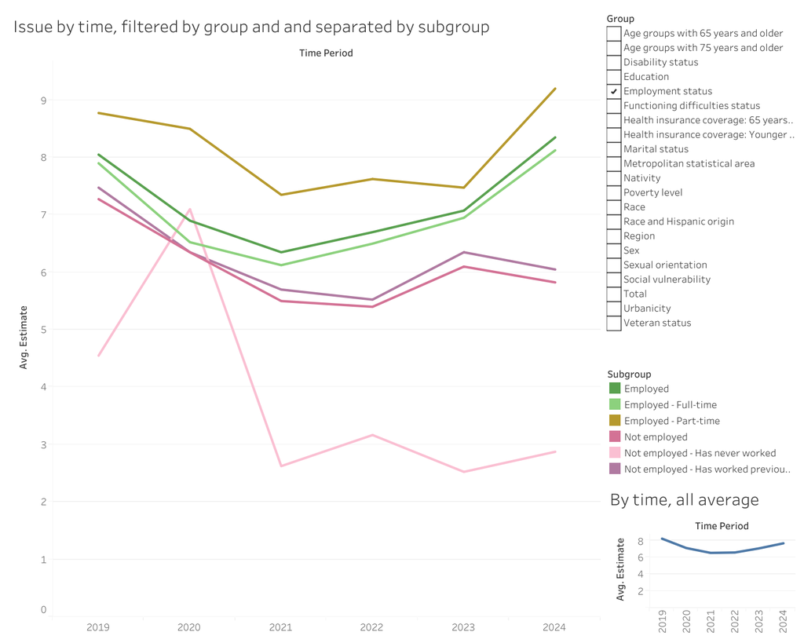

```python
Image(filename="Dashboard_by_time.png")
```

## Key Findings, Recommendations, and Future Exploration

Here are the **key findings** from the Adult Summary Health Statistics dataset through data cleaning, exploration, analysis, and visualization:

**1.** Uninsured individuals under 65 years old experience the highest rates of delayed or unmet care (around 30%)  
**2.** People who are young, Native Hawaiians/Pacific Islanders, female, bisexual, part-time employed, or living in the southern region are have the least access to healthcare.  
**3.** Generally, access to healthcare increased from 2019 to 2021, but declined from 2022 to 2024. This may be related to the COVID-19 pandemic.

**Recommendations** to increase healthcare accessibility:

**1.** Develop or expend programs to support uninsured individuals under the age of 65. Target groups with the most limited healthcare access mentioned above. Potential programs could include:

- Provide guidance to young individuals who may have just left their family's insurance plan to find a new plan that fits their needs.
- Develop cultural specific insurance plans for Pacific Islanders. Provide multilingual service.
- Include plans that support part-time employees who may not have insurance covered by their employer.

**2.** Invest in programs or infrastructure that can support communities with limited healthcare access, such as:

- Provide care that emphasize inclusiveness for the LGBTQ+ community
- increase the number of clinics, transportation to healthcare, or opportunites for telehealth services in the southern region

**3.** Investigate prepandemic and post-pandemic policy changes and develop a more sustainable healthcare system.

Here are a few areas for **future exploration** that would help uncover more insights beyond this dataset:

**1.** Look at longer-term healthcare access trends and identify key history moments, such as policy change, disease outbreak, economic events, or global affairs.  
**2.** Explore more specific states, counties, or cities with limited access to healthcare. Build models to help determine areas to increase health care access that will help the most people efficiently and effectively.  
**3.** Continue data collection and analysis for the current groups. Consider including smaller and more subgroups to help pinpoint populations more accurately.

## Archieve

This includes some of my attempts that did not end up working out. Content here can be disregarded. However, this was part of my process and I would still like to include this in the end as this is also a valuable part of my exploration.

```python
# plot by subgroup function (6 subplots)
import textwrap

def plot_by_subgroup(df, topic, groups):
    fig, axes = plt.subplots(3, 2, figsize=(15, 20))
    axes = axes.flatten()

    for i in range(len(groups)):
        group  = groups[i]
        plot_df = df.loc[df["TOPIC"] == topic]
        plot_df = plot_df.loc[plot_df["GROUP"] == group,
                         ["SUBGROUP", "ESTIMATE"]].groupby("SUBGROUP", as_index=False)["ESTIMATE"].mean()
        plot_df["SUBGROUP_WRAP"] = plot_df["SUBGROUP"].apply(
            lambda x: "\n".join(textwrap.wrap(x, 12))
        )
        axes[i].bar(x=plot_df["SUBGROUP_WRAP"], height=plot_df["ESTIMATE"])

        axes[i].set_xlabel(group)
        axes[i].set_ylabel("Estimate Percentage")
        axes[i].set_title(f"Estimates by Subgroup for {group}")

        # axes[i].tick_params(axis='x', labelrotation=45)

    # plt.tight_layout()
    plt.tight_layout()
    # plt.title(f"Estimates by Group for {topic}")
    fig.suptitle("Topic: " + topic, fontsize=20)
    plt.subplots_adjust(top=0.93)
    plt.show()
```

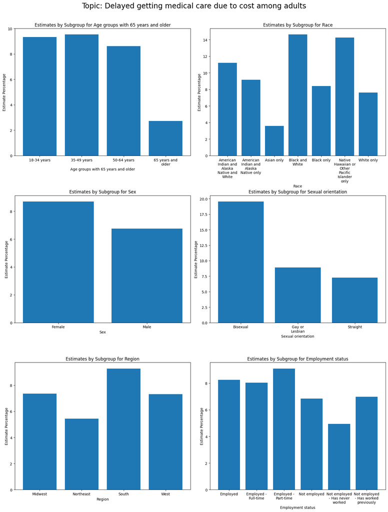

```python
# topic: Delayed getting medical care due to cost among adults
plot_by_subgroup(df_access, topic="Delayed getting medical care due to cost among adults",
                 groups=["Age groups with 65 years and older", "Race", "Sex", "Sexual orientation", "Region", "Employment status"])
```

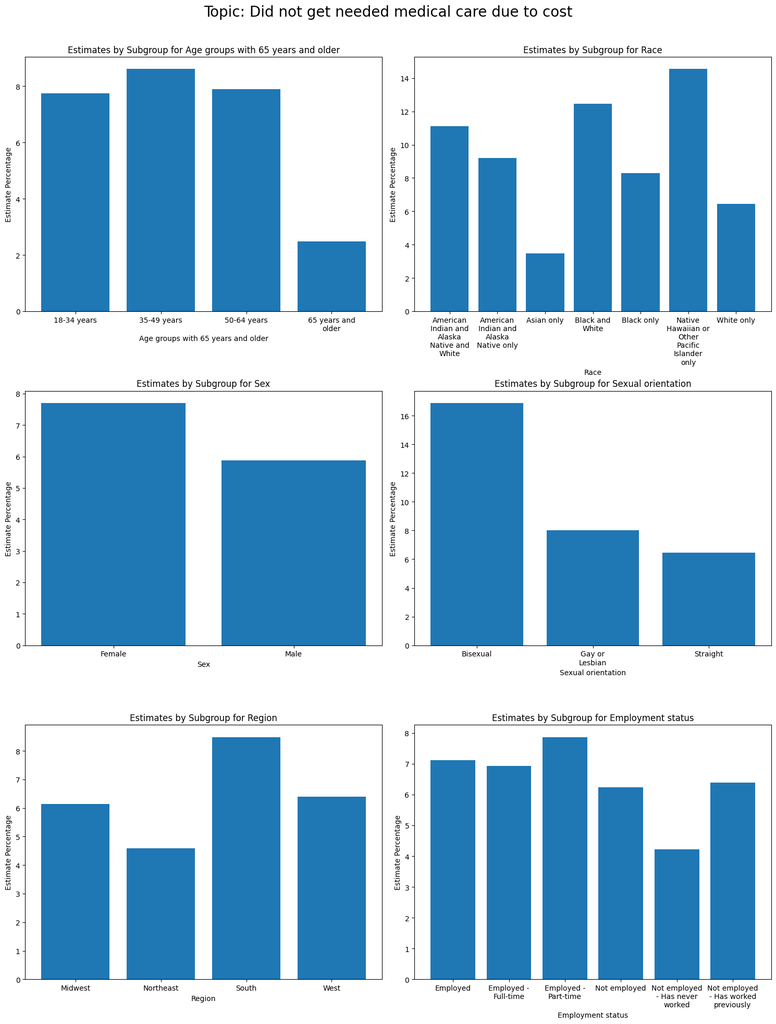

```python
# topic: Did not get needed medical care due to cost
plot_by_subgroup(df_access, topic="Did not get needed medical care due to cost",
                 groups=["Age groups with 65 years and older", "Race", "Sex", "Sexual orientation", "Region", "Employment status"])
```

```python
# Age
plot_by_subgroup(df_access, "Race")
```

```
---------------------------------------------------------------------------
TypeError                                 Traceback (most recent call last)
Cell In[22], line 2
      1 # Age
----> 2 plot_by_subgroup(df_access, "Race")

TypeError: plot_by_subgroup() missing 1 required positional argument: 'groups'
```

```python
# race
```